# 经济指标Ⅰ：GDP

王芍

2020-12-27

> 本篇报告是经济数据分析手册系列的第一篇——`GDP`数据篇。`GDP`，中文名叫`国内生产总值`，是目前衡量一国经济发展最重要的宏观指标，甚至没有之一。在本篇报告中，我们从书本到实际，在向读者呈现出统计局是如何一步步核算出我们所熟知的GDP数据后，给出了一个GDP的具体分析框架。一是总量分析，二是结构分析，后者又包括生产法和支出法两个视角，通过这两个视角，可以大致把握中国经济的产业结构和需求变化。最后结合这个分析框架，将改革开放以来的历史，分为1978年到2001年、2002年到2011年和2012年至今三个阶段，分阶段对中国GDP增长史做简要复盘。

## 1.书本上的 GDP

让我们先来复习一下教科书对于GDP的经典定义： 一国（地区）在一定时间内生产的所有最终产品的市场价值。

关于这个定义，有几点需要把握：

第一，GDP 只限于在本国内的生产。比如小明是个中国人，他在美国长期工作，她创造的产出不计入中国 GDP。再比如中国企业 A，它的美国子公司创造的产出也不计入中国 GDP。而相反的，一个在中国长期工作的美国人，他的产出计入中国 GDP。

有一个和 GDP很像的概念：GNP（国民生产总值），它不考虑地域，只考虑国民身份。无论是小明的产出，还是企业 A 在美国的子公司产出，都计入中国 GNP。

第二，“一定时期内”反映了GDP 是一个流量概念，而不是存量概念。小明在2020年底有100万的总资产，这是存量概念，小明在2020年赚了100万，这才是流量概念。两类概念不能直接对比。

第三，GDP 度量的是生产，而不是售出。企业A假如生产了100万元产品，这一年只卖出了80万，最后计入这一年GDP的还是100万。一辆在2019年生产，但是在2020年才卖出的车，其实车的价值已绊计入了2019年GDP中。

从另一个角度理解，企业A卖给了消费者80万，又把剩余的20 万“卖”给了企业自己，而后者其实已经计入了存货投资，所以这一年的GDP有100 万。

第四，GDP考虑的是最终产品的价值，或者说是每个产品环节的增值。最终产品是GDP概念中相对难理解的部分。我们用一个例子说明：

- 1）小麦厂A种植小麦，把小麦以10元的售价卖给面粉厂B。
- 2）面粉厂B把小麦磨成面粉，并把面粉以20元的售价卖给面包厂C。
- 3）面包厂把面粉加工成面包，以30元的售价卖给小明。

到了小明这，面包不再作为原材料，继续进入下一个生产环节，而是直接被消费掉了，这时面包就是最终产品，计入GDP的是30元。为什么不考虑小麦和面粉的价值呢？因为它们作为原材料，已经包含在面包的价值里了，如果把它们的价值也计入，GDP显然就重复计算了。

当然，我们也可以把GDP理解为“新创造的价值”的总和，从增加值的角度看。在小麦的环节，价值增值是10元（假如其种植成本可以忽略不计），面粉、面包的环节价值增值也都是10元。加起来合计30元，和利用最终产品价值计算出的GDP结果是一样的。

事实上，在实务中，我们很难去一个个辨别哪些是最终产品，哪些是中间产品。所以反而是用行业增加值的思路来核算GDP。

理论上来说，GDP有三种核算方法。分别是生产法、收入法、支出法。三者在核算理念上有所区别：

1）生产法：一国最终的产出成果，等于各生产环节的增加值加总。各个生产环节的增加值=总产出-中间投入。

2）收入法：一国最终的产出成果，等于各类已投入生产要素应获得的回报。比如劳动力要素要得到工资回报，资本得到利息回报。

3）支出法：一国最终的产出成果，等于最终使用。最终产品被使用的方式主要有三种，消费、投资和净出口。

尽管三者的核算理念不同，但是最终的理论核算结果是一致的。我们可以用一个简化的经济运作模型来解释这一点。

假设一国只有企业部门和居民部门：

1）企业A生产出100元钢材，全部卖给企业B。企业B拿这些钢材继续生产出200元机械设备和100元五金用具。由于只考虑最终产品，那么GDP就是300元（生产法）。

2）如果居民部门买下了100元五金用具，形成了居民消费支出；企业A买下了200元机械设备，形成了固定资产投资，那么消费+投资构成的GDP也是300元（支出法）。

3）企业A在卖出钢材后，获得收入100元，假设生产成本低到可以忽略不计，那么在向居民支付50元工资后，还剩下利润50元。企业B的收入是300元，扣除100元钢材成本，再向居民支付100元工资后，还剩下企业B利润100元。居民部门工资收入+企业A、B利润合计300元（收入法）。

换言之，生产法衡量的是创造了多少新产品价值，支出法衡量的是这些产品是怎么被使用的，收入法衡量的是产品带来的价值/利益是怎么分配的。三者是在说一件事的不同侧面。

{{% center %}}

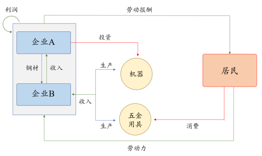

{{% /center %}}

一个简单的两部门经济运作模型

## 2.现实中的GDP

> 那么，现实中的GDP究竟是怎么核算出来的，它和书本上的GDP有什么区别？了解这个问题很重要，毕竟我们只能基于现实中的GDP指标来做经济分析。

GDP核算是一个浩大的工程。在这里，我们暂时忽略掉那些统计技术上的细节，只把一些主要的概念、方法和核算步骤展现出来，让读者对GDP这个非常“宏观”的概念，能够有更直观的理解。

### 2.1统计范围的界定

目前中国的GDP核算方法，主要是基于《中国国民经济核算体系2016》，而这一核算体系又主要参考了联合国制定的国民账户体系SNA（2008）。

根据《中国国民经济核算体系2016》，GDP的定义为：一个国家所有常住单位在一定时期内生产活动的最终成果。

其中，又主要在两个方面对GDP的统计进行了界定。

统计哪些生产主体？主要是我国的常住单位。它具体指的是在我国经济领土范围内“具有经济利益中心的经济单位”，是有门槛的：

1）要在我国有一定的场所，比如住房、厂房或其他建筑物。

2）要从事一定规模的经济活动并超过一定时期（一般是1年）。

统计哪些生产活动？中国当前的核算体系，明确界定了纳入GDP考察的四类生产活动：

1）生产者提供或准备提供给其他单位的货物/服务的生产。

2）生产者用于自身消费、投资的货物的自给性生产。

3）生产者（非住户部门）用于自身消费、投资而进行的知识载体产品的自给性生产。

4）自有住房提供的住房服务，以及雇佣有酬家庭服务人员提供的家庭和个人服务的自给性生产。

总的来说，这个界定涵盖了很多自给性生产活动（包括2、3、4），所以其实是比传统教科书上对GDP生产活动的界定（主要针对市场性活动），要更宽泛。

关于GDP生产范围的界定，历史上其实是在不断拓宽的。1993年SNA体系主要将自给性的货物生产纳入核算范围，2008年SNA体系则主要纳入了自给性的知识载体产品生产。我国这几次更新的核算体系也跟随调整，和SNA基本保持了一致。

当前GDP核算不包含的生产活动，主要是居民自给性的服务生产，比如小明给自己家打扫卫生，这种活动的价值不计入GDP。一方面是因为这些纯粹的非市场活动很难合理估价，另一方面，如果把它们也纳入GDP统计范围，会降低GDP对于经济分析和政策制定的参考价值。  
当然，统计范围只是划定了边界，受限于现实的统计能力，其实不是所有的经济主体、所有的生产活动都被仔细地考量和核算过，GDP没办法百分百地反映一个国家的生产状况。这一点，我们接下来看GDP的核算流程就会知道。

### 2.2 怎么核算生产法GDP？

目前中国对外公布的GDP数据，以生产法GDP为主，更准确来说是生产法+收入法混合。我们先来介绍这种方法。

生产法GDP，其实就是各行业的增加值加总。那么，第一步就是合理划分经济行业。

我国GDP统计，主要基于《国民经济行业分类标准》。目前该标准已经更新到了2017年版，2019年之后的GDP核算，已经采用了最新的行业划分标准。

根据该标准，可以将我国经济划分为20个门类行业、97个大类行业、473个中类行业以及1381个小类行业。

考虑到资料可获得性和工作复杂度，实际GDP核算涉及的行业细分程度是有限的。

其中，季度GDP核算能够拿到的基础资料不是很详细，所以主要基于19个门类行业（不含国际组织），部分门类行业会进一步细化为行业大类。

年度GDP核算则基本可以细分到所有大类行业来核算，不过也稍微做了一些调整，例如房地产业会继续拆分为5个中类行业来核算。

另一种分类方法，则是按照三次产业进行分类，即所谓的第一、第二、第三产业。这三大产业，基本上是对20个国民经济门类行业的再组合，不过根据最新的三次产业分类标准，一产、二产中一些辅助性的活动，被划入了三产。

具体的三次产业和国民经济行业组合方式如下图所示。

{{% center %}}

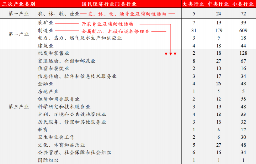

{{% /center %}}

三次产业划分和国民经济行业分类方法

在有了行业划分后，第二步就是获得各个行业的基础统计资料。季度GDP核算，统计局能拿到的资料主要包括：

1）统计局搜集的调查资料，比如各种农林牧渔业、工业、建筑业统计调查资料。

2）其他部门的行政记录资料，比如央行的金融机构信贷收支数据、税务局的分行业税收数据等。

年度GDP核算能拿到的资料更多一些，除了国家统计调查资料和行政记录资料外，还可以获得：

3）部门年度财务统计资料，比如交通部汇总的交通行业年度财务统计数据等；  
4）财政决算资料。  
不同行业有着相应的官方统计资料。但总的来说，常规年度GDP就是在上述4类原始资料的基础上加工、整理出来的。

{{% center %}}

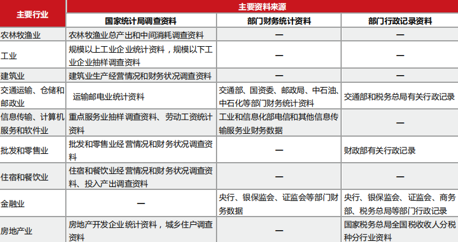

{{% /center %}}

一些主要行业的增加值核算基础

资料来源：《中国主要统计指标诠释（第二版）》

资料到手后，第三步就是分别计算各行业的增加值。在实际核算过程中，有两点需要注意：

第一，根据我国目前的GDP核算方法，农业、林业、渔业、牧业等行业增加值采用生产法核算，其他行业则采用收入法核算。

- 1）生产法核算方法：行业增加值=总产出-中间投入。

以农林牧渔业为例，统计局要从农林牧渔业统计报表中，拿到农林牧渔业总产值数据，以及中间消耗数据，再用总产值-中间消耗，计算增加值。

- 2）收入法核算方法：行业增加值=劳动者报酬＋生产税净额＋固定资产折旧＋营业盈余。

这四个项目的定义以及计算方法示例，我们在下表中列示。由于各个项目在核算过程中，有很多细节问题需要处理，不同行业具体计算方式也不同，限于篇幅，这里就不展开谈了。

简单以建筑业为例，统计局要从建筑业企业财务状况表、生产经营情况表中，获得企业的各种财务数据，然后基于这些财务数据，分别计算出劳动者报酬、生产税净额、固定资产折旧和营业盈余四大项目，最后加总得到行业收入法增加值。

不过，上述说法仍然简化了核算过程，因为建筑业中有很多资质外建筑企业、个体经营户等，他们都缺乏官方的统计资料，最终需要通过推算，才能得到他们的增加值，我们下文会讲到。

{{% center %}}

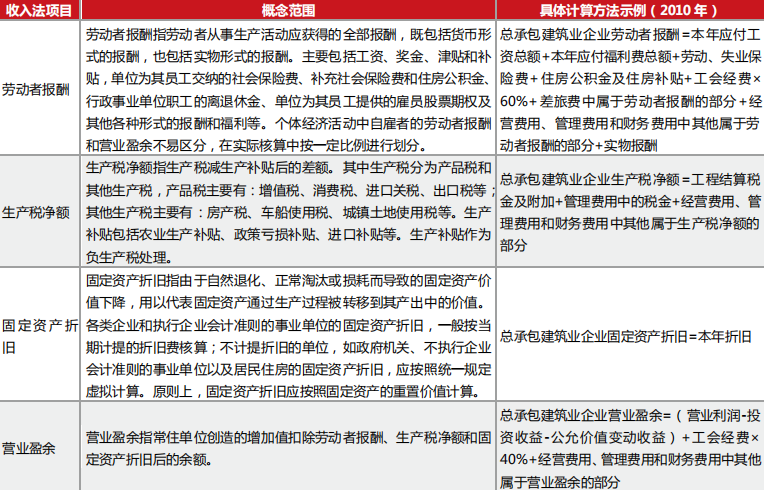

{{% /center %}}

四个收入法项目的概念范围和计算方法示例

资料来源：《中国国民经济核算体系 2016》、《中国非经济普查年度GDP核算方案（2010年修订版）》

第二，部分资料丰富详实的行业，可以直接计算增加值数据。而资料不足的行业，需要进行推算。特别是季度GDP核算，由于资料限制，很多行业都需要采用推算方法。

推算的方法主要有三种：比例推算法、增加值率推算法、相关指标推算法。

1）比例推算法。例如建筑业有很多资质外建筑企业，统计局缺乏他们的生产数据，那么只能先计算出今年资质内企业的增加值，再参考过去资质内企业的增加值占全行业比重（一般是基于经济普查数据来计算这个比重），反推出整个建筑业的增加值。

2）增加值率推算法：增加值＝总产出×增加值率。

例如租赁和商业服务业，在采用收入法核算的时候，四个构成项目没办法直接核算，那么只能参考过去四个项目占总产出的比例，再用今年的行业总产出×收入法各项目占比，得到各项目推算数据，再加总获得行业增加值。

3）相关指标推算法：增加值＝上年同期增加值×（1＋相关指标增长速度）。这里的增加值也可以换成总产出，或者收入法各项目。

例如仓储业，统计局可以获得仓储服务企业的营收增速，今年的仓储业总产出，可以用去年仓储业总产出×营收增速计算得到。然后再用增加值率推算法，进一步算出仓储业的收入法增加值。

因为间接计算是一种估算，一定程度上会影响GDP的核算精确度。大部分的行业其实是直接计算和间接计算混用。2013年数据显示，利用基础资料直接计算的行业增加值约为GDP的55%，采用间接计算的约为45%。随着这几年统计资料不断丰富和完善，现在直接计算的比例可能会更高一些。

可以发现，GDP核算其实并不能做到绝对“精确”，它某种程度上还是一个估算值。  
{{% center %}}

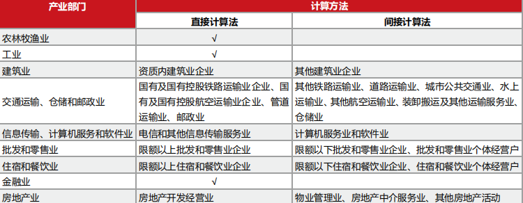

{{% /center %}}

少数行业完全采用直接计算方法，大部分是直接和间接计算方法混用

资料来源：《中国现行国内生产总值核算方法》、许宪春（2014）

最后，在计算出了各个行业的增加值后，把它们全部加总起来，就可以得到最终的生产法 GDP。

### 2.3怎么核算支出法GDP？

另一种核算GDP的方法是支出法。支出法GDP尚未建立正式的季度核算制度，因此目前只披露年度数据。

在支出法下，GDP被分为最终消费支出、资本形成总额、货物和服务净出口三部分来进行核算。

最终消费支出主要包括居民消费支出和政府消费支出。

居民消费支出总共包括10个类别：1）食品烟酒。2）衣着。3）居住。4）生活用品及服务。5）交通和通信。6）教育、文化和娱乐。7）医疗保健。8）金融中介服务。9）保险服务。10）其他商品及服务。

这些类别的数据，1-7和10主要基于住户调查中的居民消费支出资料来计算（住户调查是抽样调查），不过也参考了行政记录资料、行业协会数据等其他资料，比如“交通和通信”类别中的汽车消费支出，会参考汽车工业协会的轿车销量等数据进行推算。8和9则主要参考金融和保险业统计资料计算。

政府消费支出，与财政支出密切相关，但需要进行一些调整。

财政支出包括两部分，一部分是购买性支出，一部分是转移性支出。购买性支出又包括政府消费性支出（也称经常性支出）和政府投资性支出，两者最大的区别在于，前者是非生产性的，不形成任何资产。只有经常性支出算作政府消费支出。

具体地，GDP下的政府消费支出=财政支出中的经常性业务支出-经营性业务收入+固定资产折旧。其中经常性业务支出，主要是指工资福利性支出、商品和服务性支出等。相关数据主要来自于财政支出决算明细表。

资本形成总额主要包括固定资本形成总额、存货变动。

固定资本形成总额指的是常住单位在一定时期内获得的固定资产减处置的固定资产的价值总额，可分为有形和无形两部分。

在具体操作中，主要按照8个分项计算：1）住宅。2）非住宅建筑物。3）土地改良支出。4）机器和设备。5）矿藏勘探费。6）计算机软件支出。7）研究与开发支出。8）其他支出。

固定资本形成总额主要是基于全社会固定资产投资额计算出来的，但同时也做了一些调整，关于两者的差别我们将在下文中提到。

存货变动按照8个行业分别计算：1）农林牧渔业。2）工业。3）建筑业。4）批发和零售业。5）交通运输仓储及邮政业。6）住宿和餐饮业。7）房地产业。8）其他服务业。

每个行业的存货变动，都通过相应行业的统计调查或财务资料，获取期初、期末存货价值数据来进行核算。

计算存货变动时，剔除了价格变动所引起的存货持有收益/损失。因此存货变动=期末存货价值-价格调整后的期初存货价值。

货物和服务净出口，主要由货物与服务出口金额-进口金额计算得出。相关数据直接取自于国际收支平衡表。

最终消费支出、资本形成总额、货物和服务净出口三者加总，即得到支出法GDP。

理论上支出法GDP与生产法GDP最终的核算结果是相等的，但在实务中，由于在两者在统计资料、统计方法下的差异，核算结果会存在误差。因为我国以生产法GDP为准，所以这一统计误差项最终填列在支出法（使用方）栏目下。  
{{% center %}}

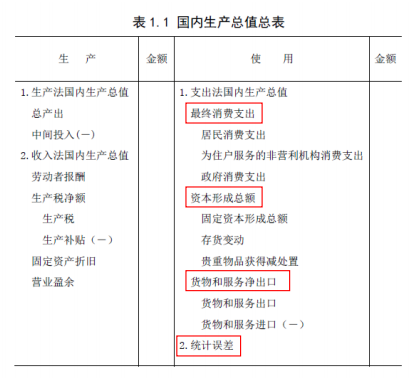

{{% /center %}}

支出法和生产法GDP之间的统计误差填列在支出法下

资料来源：《国民经济核算体系2016》

### 2.4名义GDP和实际GDP

统计局在核算GDP时，会同时核算现价GDP和不变价GDP，它们也被分别称作名义GDP和实际GDP。

它们有什么区别？我们用一个例子进行说明：

举个例子，假设A国只生产汽车：

2015年，一辆汽车的价格是10万元，到了2020年，一辆汽车的价格涨到了20万元。

如果2020年A国生产了100辆汽车，那么这一年的名义GDP就是2000万元（简单假设中间投入为0），即2020年价格×2020年数量。

而2020年的实际GDP（指定基期为2015年）则只有1000万元，即2015年价格×2020年数量。

换言之，名义/现价GDP是用现在的价格计算的GDP，实际/不变价GDP是用基期价格计算的GDP。

注意，基期是可以随意变化的，如果选择了不同的基期，那么实际GDP的数值会存在差异。所以我们在说明实际GDP的绝对额时，一般要指明基期。

为什么我们还要使用实际GDP这个概念呢？因为实际GDP通过保持基期价格不变，进而剔除了价格因素，能够更纯粹地反映产出数量变动的影响。

在实际统计中，统计局核算不变价GDP也是采用生产法和支出法。

从生产法的角度看，不变价GDP由各行业的不变价增加值加总而得，它的核算是和现价GDP核算同步进行的。

计算各行业不变价增加值的方法有两种：价格指数缩减法、物量指数外推法。不同行业用的方法不同，相关的价格/物量指数也不同。

价格指数缩减法：行业不变价增加值=行业现价增加值÷价格指数。

比如工业，用的是工业生产者出厂价格指数来缩减，建筑业，用的是建筑安装工程价格指数来缩减。

物量指数外推法：行业不变价增加值＝上年同期不变价增加值 ×（1＋物量指数增长速度）

有一些行业，更方便得到的指标是物量指标，比如铁路运输业，可以利用铁路客货运周转量指数，在上期增加值的基础上，直接外推出当期不变增加值（因为只考虑了“量”的变化，价格还是保持了基期价格）。 {{% center %}}

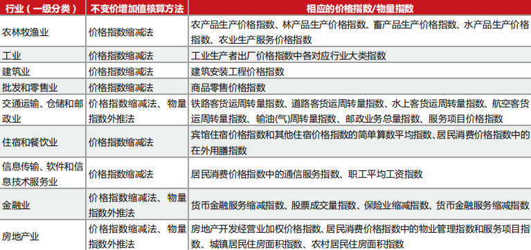

{{% /center %}}

部分行业采用的不变价增加值核算方法及相关的价格/物量指数

资料来源：《准确理解中国现行国内生产总值核算》、许宪春（2019）

不变价GDP的支出法核算方式，与生产法是一致的，也是主要采用价格指数缩减法、物量指数外推法。

目前只有少部分支出项目，采用的是物量指数外推法，比如“GDP-居民消费支出-居住项“中的自有住房住房服务价值，使用“居民自有住房面积发展速度”这一物量指数进行外推。其他绝大部分项目，采用的都是价格指数缩减法。

不过，支出法下的不变价GDP还处于试算阶段，部分项目的核算还有待完善，比如政府消费支出、存货变动、净出口等。因此目前并不对外公布不变价核算结果，而只是公布三大支出项目对GDP不变价同比的贡献率和拉动点数。

另外，在实际GDP的基期选择问题上，统计局也有相关规定。

目前计算不变价GDP需要每隔若干年调整一次基期。在1981年到2000年间，是每10年调整一次基期。 而自2001年至今，是每5年调整一次基期，例如2011-2015年的实际GDP，以2010年为基期计算，2016-2020年数据则按2015年价格计算。

在核算了现价GDP和不变价GDP之后，为了衡量它们之间的关系，有一个专门的指标，叫做GDP平减指数。

统计局公布的GDP平减指数=当期现价GDP÷当期不变价GDP。这里的不变价GDP，采用的基期为上一期，即每一年（季）的GDP平减指数计算，都以上一年（季）价格作为不变价。

因为现价GDP未剔除价格因素，而实际GDP剔除了，所以两者相除得到的GDP平减指数，其实可以看作我国所有最终货物和服务的价格总指数。

该指数与我国常用的其他的CPI、PPI等价格指标不同。

一是核算思路有所不同。CPI、PPI等指数是直接编制的价格指数，而是GDP平减指数是将现价GDP与不变价GDP相除得到的（不过在计算不变价GDP时，有些行业增加值的计算，可能利用CPI或者PPI数据进行价格缩减，这是它们的关联所在）。

二是统计范围有所不同。CPI只考虑居民消费相关的商品和服务，PPI则主要反映工业企业产品的价格，而GDP平减指数则涵盖了所有生产的货物和服务。

### 2.5GDP数据的修订

季度GDP的初步核算数，一般是季后15天左右公布。年度GDP的初步核算数，一般是次年1月20日左右公布。

GDP在初步核算后，还需要进行最终核实。

而季度、年度GDP的最终核实数，则一般要到隔年1月份才会出来。

相比于初步核算，最终核实数参考的资料会更丰富，比如能拿到财政决算资料、行业财务资料，计算得到的GDP数据也会更准确。

上述属于常规修订，此外中国历史上还有几次GDP的全面修订。

如果GDP核算方法变化，或者行业分类标准发生变化，那么统计局就会对GDP历史数据进行全面修订。最典型的就是2017年中国国民经济核算体系重大调整，将研发支出纳入了GDP，随之更新了历史GDP数据。

另外，每次开展全国经济普查后，由于对第二、三产业开展了全面性调查，有了范围更大、内容更丰富准确的基础数据，往往也会对年度、季度GDP历史数据进行修订。

第一次经济普查在2004年，之后逢3和逢8年份为经济普查年。目前我国一共开展了四次经济普查，分别是2004、2008、2013、2018年。

普查年的次年12月左右会发布经济普查数据，并且对普查年及以前年份的GDP数据进行修订。

这四次经济普查，对普查年名义GDP的修订幅度分别为+16.8%、+4.4%、+3.4%、+2.1%，修订幅度基本上是越来越小，这也反映了中国GDP数据统计质量在不断改进。

经济普查对GDP的修订，可能会对经济预测造成一些影响，所以也比较受市场关注。

例如2020年是中国全面建成小康社会的关键之年，根据十八大目标，我国国内生产总值需要较2010 年翻一番。按照这一信息，可以推算出2020年需要达到的GDP增长目标。

在第四次经济普查对实际GDP同比增速的影响没有出来之前，预估2020年实际GDP增速需要达到6.1%左右，才能完成翻一番目标。但是在第四次经济普查修订结果出来后，历史GDP增速被调高，使得2020年GDP增速只需要达到5.5%，就能实现GDP翻番目标，这就使得当时市场对经济刺激政策的期待进一步降温。

最后我们可以观察一下，在经历了历史多轮修订后，当下最新的GDP同比增速和各年初步核算的GDP增速之间有什么差异。

首先，修订后各年的GDP同比增速基本都更高了。

其次，修订前后的GDP差异，在这几年越来越小。这可能是因为历史GDP核算与现在有很多细节方面的不同，从后往前回溯修订更困难，所以数据差异也越大，另一方面也可能和近年来参考资料的丰富、核算质量的提高有关。 {{% center %}}

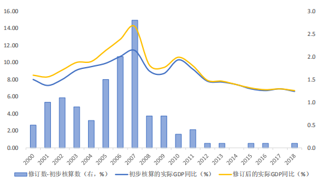

{{% /center %}}

多轮修订后的GDP 同比，比初次核算的 GDP 同比要更高

### 2.6地区GDP加总≠全国GDP？

最后有一个常见问题：如果将各省份的GDP加总，按理来说应该等于全国GDP，但事实上两者并不一致。

{{% center %}}

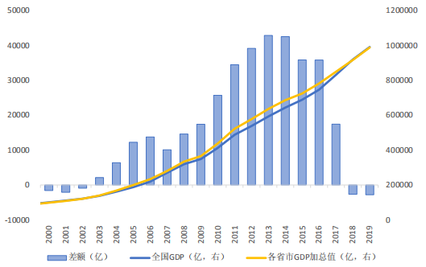

{{% /center %}}

地区GDP合计值多年来高于全国 GDP，但 2018-2019 年差异显著缩小

该如何理解这两者之间的误差？

第一，差异存在的一个重要原因在于分级核算制度，即国家统计局核算全国GDP，各省统计局核算各省GDP。这会带来几个问题：

1）在GDP核算过程中，每个省和全国能够掌握的基础资料可能有差异，有时采用的推算方法也不同，所以在统计上会有一些误差。

2) 地方核算GDP时，很难去仔细辨别跨地区的生产经营活动，例如某公司在A市设立母公司，B、C两市分别设立子公司，那么到了年末，B、C两地在核算地区GDP的时候，就有可能将子公司创造的增加值记在当地的GDP中，造成重复计算。

3）基层的统计力量可能相对薄弱，统计人员可能配置不足、业务水平不高，这都会影响地方GDP的统计质量。

第二，有些地方政府为了彰显政绩，可能会给GDP数据注水，导致GDP虚高。天津、辽宁、内蒙古等地都曾曝光过本省的经济数据造假行为。国家统计局也曾公开过多起统计违法案件，地方统计工作人员编造并代填代报企业统计数据，人为拉高地方GDP。

上述主客观原因，共同导致了地方GDP加总值高于常年高于全国GDP。 该如何理解这个误差在2017-2019年的缩小呢？

如果地区GDP加总持续与全国GDP存在较大差异，可能会让人质疑GDP核算的客观性，也很难基于GDP数据，来分析地区的经济结构。

2019年我国提出GDP统一核算改革，即不再是地方自行核算GDP，而是由国家统计局领导，各省统计局参与，统一进行核算。

借助于第四次经济普查，2018年GDP已经进行了统一核算，并有了修订结果。调整之后，地区GDP加总略小于全国GDP。这主要是因为有一些生产活动，比如驻外使领馆、军队武警，以及一些不宜划分地区的保密单位，它们的活动仅核算在全国，地区GDP是不核算的。

从调整后数据来看，各省GDP数据都或多或少有一些变动。其中，山东、天津、河北与东北三省等14个省（直辖市）下调；安徽、上海、福建、广东和浙江等17个省（直辖市）上调。总体来看，调高的省份以南方居多，调低的省份以北方居多。

未来，随着GDP统一核算的改革调整，地方GDP合计值和全国GDP之间的差异将显著缩小，并且这个差异可能会保持一个相对稳定的负值。

{{% center %}}

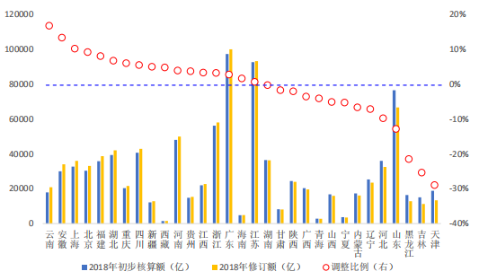

{{% /center %}}

2018年各地区GDP的初步核算值以及统一核算后的修订值对比

数据来源：政府官网

## 3.我们如何分析GDP？

现在，假如有一仹刚公布的季度/年度GDP数据摆在我们面前，我们该如何解读？又该如何简单地预测GDP走势？

### 3.1总量分析

GDP分析分为两步走，第一步看总量，第二步看结构。

先来看看GDP绝对额。季度GDP在公布时，一般会有两个值，累计值和当季值，在这里我们需要简单区分一下这两者。

累计值是指年内累计，比如2季度GDP累计值，是指1-2季度的GDP。而2季度GDP当季值则仅指2季度GDP。

在2015年3季度之前，GDP采用的是累计核算方法，公布的也是累计值，当季GDP数据需要推算。比如根据2019年1-3季累计GDP，再减去1-2季度累计GDP，得到3季度当季GDP。

因为累计值通常会包含对前面季度数据遗漏、重复及误报的调整，所以在2015年之前，用累计GDP推算当季GDP，将不可避免地造成一些统计误差，不能得出真正意义上的当季GDP。

假如我们用历史公布的季度GDP累计值（初步核算数），来推算历史当季GDP。可以发现在2015年以前，这个GDP当季推算数在1、2、3季度均被低估，而在4季度存在明显高估，整体波动性会更大。

到了2015年3季度后，才正式建立分季的GDP核算制度。这时，其实是先核算出当季的GDP，然后加总各个季度的当季数据，得到累计数据。

所以这时候用累计值反推出的当季值，其实和官方公布的当季值数据基本是一致的。只有每年的4季度数据除外，因为1-4季度累计GDP，其实就是年度GDP，这时会根据新资料再做一些调整，所以按照1-4季度累计值反推出的4季度GDP当季值，会与公布数据有一定差异（当然这里只是指初步核算值，之后的GDP修订工作会把差异都抹平）。

我们现在一般在分析季度GDP数据时，当季值和累计值都可以看，但一般分析的是官方公布的GDP当季值。

{{% center %}}

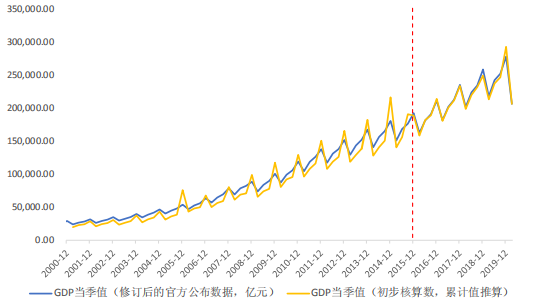

{{% /center %}}

2015年之前，用GDP累计值推算的当季值存在较大误差

紧接着，如果观察我国GDP当季值变动趋势，可以发现，长期来看GDP一直处于扩张趋势。每年的GDP一般都高于上年，各季度GDP一般都高于上年同期。

另外我们也可以发现非常明显的季节性规律，每年的1季度到4季度，GDP绝对额是逐季增加的。这可能是由于以下几个原因导致的：

1）节假日因素。比如一季度有春节，企业停工停产。

2）农作物生长周期。主要农作物的收成期一般是下半年。

3）消费、出口旺季在下半年。这可以从社会消费品零售额、出口金额年内波动趋势看出。

正是因为GDP数据存在明显的长期增长趋势和季节性波动，所以对比GDP绝对额意义并不大。

事实上，我们更关心的是变动率，即经济增长速度的快慢。另外，我们还需要一些办法，来剔除季节性波动，以便把握经济变化的主趋势。

一个传统的处理办法是计算GDP同比。通过比较当季GDP与上年同一季度的GDP（具有相同季节性），就可以剔除季节性因素的影响。

这里需要注意的是，我们使用的往往是不变价GDP同比，即所谓的实际GDP同比。

因为实际GDP同比剔除了价格因素，能让我们更清晰地识别出，经济增长中哪些是物价上涨得来的，哪些是生产/需求扩张得来的，而后者是我们此时更关注的。

各类媒体报道、学术报告中所提到的GDP增速，如“2020年1季度GDP增速为-6.8%”，若不含特殊说明，一般也都是指实际GDP同比。

另一个方法是先对不变价GDP进行季节性调整，然后再计算环比指标。

相对于同比指标而言，环比指标的好处在于，能够更及时地反应当前的经济运转状况。同比增速对比的是当季GDP和上年同季GDP，理论上来说，同比包含了好几个环比增速的连乘（存在基数效应的干扰）。而环比指标只对比了当季GDP和上季GDP，包含的历史信息更少，也就更“新”，更“灵敏”。

问题在于，计算环比之前，怎么对当季GDP进行合理的季节性调整，以剔除季节性波动呢？

2011年1季度，国家统计局建立了季度GDP环比统计制度，此后会定期公布季调后的GDP环比。统计局主要基于季节调整软件（NBS-SA）对GDP进行季节调整，该软件涉及到一些相对复杂的计量处理方法，同时考虑了中国独特国情，比如对春节、端午、中秋等假日因素进行了剔除。

下图中可以看出，在季调之后，GDP环比增速没有了季节性波动，明显更具有参考价值了。

不过目前来看，统计局公布的季调后GDP环比数据，时间区间相对较短，运用的还不是很广泛。人们更喜欢用的还是GDP同比数据。

{{% center %}}

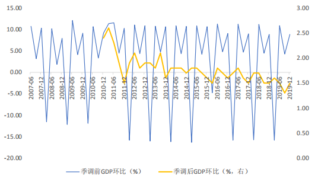

{{% /center %}}

季调后的GDP环比增速，比季调前更具有意义

注：季调前GDP环比用不变价GDP当季值进行手动环比计算，季调后GDP环比用统计局公布数值

对于海外发达经济体而言，GDP季调体系已经非常完善，所以会直接公布季调后的GDP绝对值，美国、日本、欧盟都是如此。

例如美国开发了自己的季调工具（X-13 ARIMA），季调因素包括假期因素、月工作天数，甚至还综合考虑了冬季天气、工厂生产计划等一系列因素。

而由于有了比较科学的季调数据，所以这些国家更关心的是GDP的环比指标，而不是同比指标。

关注海外经济的读者，应该会对“环比折年率”这个概念比较熟悉。这是海外发达经济体用于描述GDP增长的主要指标。

环比折年率=（1+环比增速）^4-1，近似等于环比增速×4。这是假设经济可以连续4个季度，都保持同样的环比增长速度，进而将环比指标年化。思路有点像是我们用复利的方式，把月利率换算成年化利率。

实际上，这个指标就是把季度GDP的环比变动幅度放大，以更清楚地展示短期经济的波动情况。一般来说，GDP的环比折年率变动幅度，会大于同期的GDP同比变动幅度。

{{% center %}}

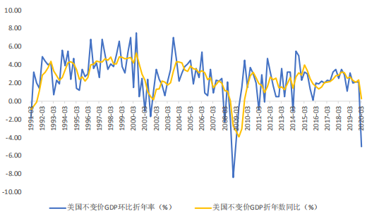

{{% /center %}}

美国GDP环比折年率波动幅度大于折年数同比

简单总结一下。目前对我国GDP进行总量分析，最主要的指标还是不变价GDP同比。

第一，我们可以先拿它和机构预测值进行对比，看是超出预期还是低于预期。

第二，我们可以拿它和历史数据比，看是走高还是走低，变动斜率如何。

第三，我们可以拿它的变动情况和海外主要经济体的GDP数据变动进行对比，看看走势是否具有一致性，增速谁高谁低。但是在对比的时候，注意同环比指标的差异性。

### 3.2结构分析

在对GDP数据进行了总量分析后，接下来我们需要深入分析GDP的结构。有两个基本视角，一个来自于生产法，另一个来自于支出法。

生产法GDP是各行业增加值的加总，分析生产法GDP的构成，实际就是在分析产业结构和产业变化。

支出法GDP由消费、投资、出口构成，通过分析这几大项，可以摸清经济需求的变化情况。

#### 3.2.1生产法视角

先来看生产法视角。我们首先需要搞清楚的是，对于GDP而言，三次产业各自的重要性如何。

从历史数据来看，我国第一产业和第二产业增加值占GDP比重都在下降，而第三产业占比正不断上升，目前已经居于主导地位。截至2019年，第一、第二、第三产业按不变价计算的GDP占比分别为7.4%、39.6%、53.0%。  
{{% center %}}

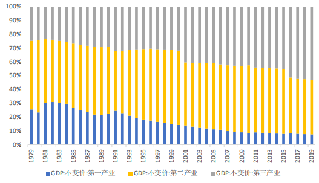

{{% /center %}}

第三产业占GDP比重不断上升

不过，我们想知道的不仅仅是三大产业的GDP占比，因为从短期来看，三次产业结构一般不会发生大变动，只有长期来看，这个数据才会呈现出清晰的变动趋势，才具备分析价值。

我们更关注的是三大产业增加值（为便于说明，下文中都直接简称为某产业GDP）在短期的变动幅度，以及它们各自对于GDP增速的影响程度。

由于统计局没有公布各产业的季调GDP环比数据，所以三大产业GDP的变化幅度，只能由不变价同比来度量。

{{% center %}}

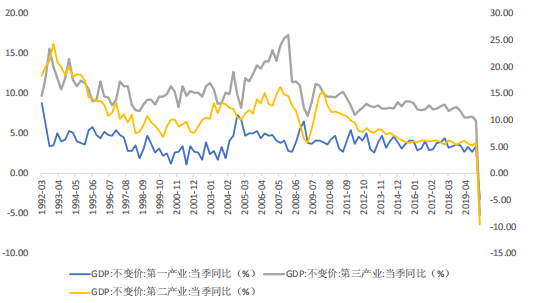

{{% /center %}}

三次产业GDP同比变动趋势

有了三大产业的GDP同比之后，可以分别计算出它们对GDP增速的拉动效果。

首先需要计算各产业的GDP增长贡献率。这个概念和各产业GDP占比有点像，不过是GDP增量的占比。

具体来说，第一产业GDP增长贡献率=第一产业GDP增量÷总GDP增量，均采用不变价计算。第二、第三产业也是同理。

统计局会公布每个季度各产业对GDP的贡献率。我们也可以手动计算得到，结果和官方公布值是相同的（但在手动计算的时候，一定要注意保持不变价GDP基期一致）。

第一、第二、第三产业对GDP增长的拉动点数之和，等于GDP同比。这样，我们就可以清晰地解构出各产业对GDP增长的影响程度。

{{% center %}}

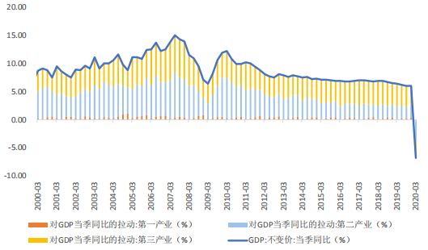

{{% /center %}}

三次产业对GDP增长的拉动点数和等于GDP同比

在上述过程中，最关键的还是对各产业的GDP同比进行分析。而无论是解读各产业GDP同比背后隐藏的信息，还是对产业GDP同比进行预测，只依靠GDP数据本身是不够的，我们需要一些相关指标进行辅助判断。

首先是第一产业。上文我们曾提到，第一产业（农林牧渔业）GDP，主要是通过总产出-中间消耗核算出来的。

因为中间消耗相对比较稳定，所以第一产业GDP的波动，主要源于农林牧渔总产值波动。农林牧渔总产值同比没有剔除价格因素，所它和第一产业的现价GDP同比走势基本上是相近的。

而第一产业现价GDP/总产值的波动，又主要源于价格波动，而非生产波动。

第一产业GDP平减指数累计同比（代表“价”）的走势，和现价GDP同比是一致的。而第一产业不变价GDP同比（代表“量”）变动则比较小。

总的来看，因为第一产业的GDP增长贡献率很低，一般都在5%左右，并且不变价GDP同比波动不大，所以我们对GDP的分析，往往也不涉及第一产业。

{{% center %}}

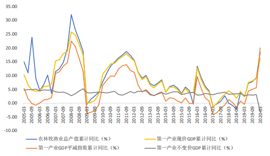

{{% /center %}}

现价GDP主要是受价格波劢影响，量的波动其实很小

不过关于第一产业，2020年1季度有一个有趣的现象。

因为新冠疫情下的物理隔离，农业生产和畜牧业养殖受到了比较大的冲击，导致第一产业不变价GDP同比，大幅走弱至-3.2%。但与此同时，第一产业GDP平减指数同比却在飙涨。说明量减，价升。

我们可以通过农产品生产价格指数同比来观察价格变动。它是统计局用价格缩减法，将农林牧渔业现价增加值转换为不变价的主要指标，所以它和第一产业GDP平减指数同比走势基本是一致的。

而在农产品生产价格指数中，畜牧业产品是1季度价格上涨的主要品种，特别是猪肉。很明显，2020年1季度，中国还处于由非洲猪瘟引起的超级猪周期中。

猪价上涨的影响，甚至全面盖过了疫情对生产的负面冲击，而把1季度现价GDP同比拉高到了16.2%。 {{% center %}}

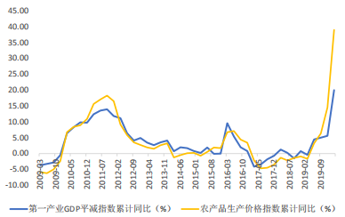

{{% /center %}}

农产品生产价格指数同比和第一产业GDP平减指数同比走势一致

{{% center %}}

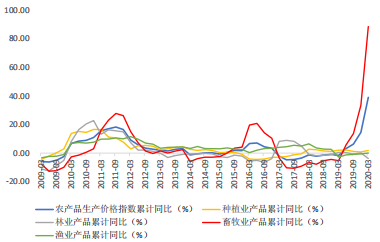

{{% /center %}}

农产品生产价格指数同比中，2020年1季度最 主要是畜牧业产品生产价格指数同比在上涨

接下来是第二产业。工业GDP占第二产业GDP比重约为85%，建筑业GDP占15%。工业占大头，GDP分析的时候一般也主要讨论工业。

工业生产状况的好坏，对于我国经济而言非常重要。因此，统计局会在每个月中旬公布工业增加值的同环比数据，以增强数据的时效性。  
工业增加值这个指标是我们分析的重点。我们目前经常用它来代替对工业GDP的分析。原因在于：

1）工业增加值是月频数据，能够帮助我们及时地跟踪工业生产的短期变化。

2）工业增加值除了公布总体增速外，还会同时公布41个子行业的增速，有利于我们深入把握各行各业的动态。

那这个独立的工业增加值指标，和GDP项目下的“工业增加值”（即我们所指的工业GDP）有什么差异呢？

最主要的差别在于统计范围。工业增加值只统计了规模以上的工业企业，即营收在2000万及以上的工业企业，而工业GDP则包含了所有工业企业。不过，规模以上企业本来就是工业企业主体，所以这一点影响也不大。

除此之外，两者都是增加值的概念，没什么差别。

工业增加值同比，本身已经剔除了价格因素，所以从历史走势来看，和工业不变价GDP同比是比较一致的。

关于工业增加值这个指标，这里不深讲，我们后续还有专门的文章对它进行介绍。  
{{% center %}}

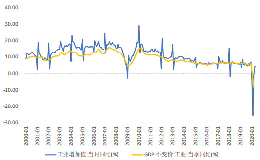

{{% /center %}}

工业增加值同比增速和工业不变价GDP的增速走势一致

最后是第三产业。随着第三产业占比不断增长，对GDP波动的影响力也就越来越大，我们不能忽视这种影响。

但是，第三产业所包含的行业范围比较广泛，目前又缺乏一个类似于工业增加值的月频综合性指标，能够跟踪服务业变化，这就增加了我们的分析难度。

尽管国家统计局自2017年开始，发布了服务业生产指数同比（剔除了价格因素），这是一个能够反映服务业经济活动的月度运行情况的综合性指标。但这个指标目前的适用性还不是很好。原因在于：

1）只覆盖了市场性活动。而服务业GDP则既包含市场性活动，也包含非市场性活动，比如科教文卫等行业中的非市场性活动。

2）不够准确。为了保证时效性，该指标能够参考的基础资料有限，并且对于部分行业采用了推算预估。服务业GDP的核算相对更完整、准确。

3）数据披露期限较短。目前该指标最早只到2016年12月。

从2017年以来的已有数据来看，服务业生产指数同比和第三产业GDP同比，在大方向上是一致的，但短期走势有所背离，服务业生产指数似乎领先了半年左右。

未来随着服务业生产指数的数据时间跨度不断拉长，核算方式不断改进，研究者可能会给予这个指标更多的关注。  
{{% center %}}

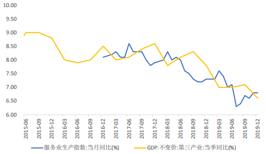

{{% /center %}}

服务业生产指数同比和GDP同比大方向一致，但短期走势有所背离

另一个可用于替代分析的综合性指标是服务业PMI指数。

但它是用调查问卷的形式统计的，和第三产业GDP的核算思路完全不同。并且它本质上是一个环比指标，不适合直接拿来与第三产业GDP同比做比较（而第三产业GDP又没有季调后的环比指标）。

不过，考虑到它是月频数据，有时效性，我们还是可以参考这个指标来简单地判断服务业的短期变化。  
{{% center %}}

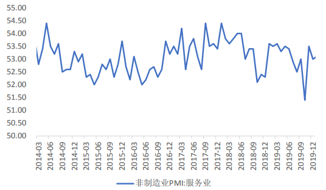

{{% /center %}}

服务业PMI可以粗略地用于判断服务业短期变动情况

由于缺乏比较完善的综合性指标，我们有时候需要分行业来具体分析第三产业。

目前，第三产业中，有8个行业会公布增加值的季度数据：  
1）批发和零售业 。  
2）交通运输、仓储和邮政业。  
3）住宿和餐饮业。  
4）信息传输、软件和信息技术服务业。  
5）金融业。  
6）房地产业。  
7）租赁和商务服务业。  
8）其他行业。“其他行业”中又包含了7个子行业，比如卫生和社会工作、教育业等。但是这些行业的增加值只披露年度数据，并且数据相当滞后，目前最新数据只到了2017年。

从披露季度数据的8个行业来看，我们可以选择优先分析那些GDP占比较高、波动性又比较大的行业，比如金融业、房地产业等，它们对GDP增速变化的影响力更大。  
{{% center %}}

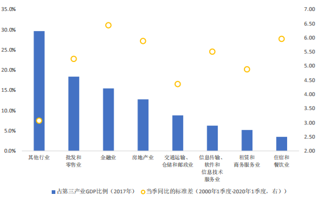

{{% /center %}}

8个服务行业的GDP占比和当季同比标准差对比

对于每个行业，我们都可以选择一些指标来拟合该行业GDP同比的变动情况，特别是那些统计局在GDP的核算过程中使用了的指标。但有两点需要注意：

1）这个指标最好是物量指标，不包含价格因素。

2）我们只能通过这些指标的变化，来分析GDP变化的具体原因，或是判断未来GDP可能存在的趋势和拐点，而很难直接测算出相应行业GDP增速的具体数值。

例如，金融业GDP同比和股票成交量月度同比，有比较明显的相关性，因为股票成交量与证券公司的经纪业务收入密切相关。这可能反过来也说明证券业的波动，可能是影响整个金融业GDP波动的重要因素。  
{{% center %}}

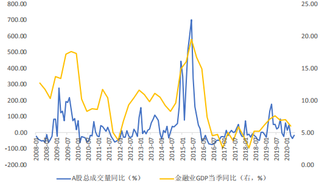

{{% /center %}}

金融业GDP同比和A股成交量同比走势相关

再例如，商品房销售面积同比的走势，和房地产业GDP同比是基本一致的。我们可以利用前者（月频数据）来判断房地产业GDP同比的拐点和变动方向。

{{% center %}}

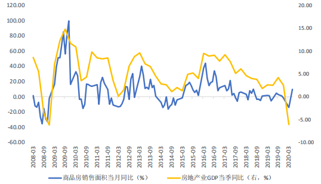

{{% /center %}}

房地产业GDP同比和商品房销售面积同比走势相关

#### 3.2.2支出法视角

接下来是支出法视角。我们一般在分析GDP时，它其实是更主要的视角。因为消费、投资、净出口作为三大主要需求变量，在短期内的变动是比较灵敏的，并且有显著的经济意义。

三大需求哪个的影响力最大？从三大需求的GDP贡献率来看（和上文提到的GDP贡献率是同一概念），目前消费变动对经济增长的影响力最显著，其次是投资，最后是净出口。

2019年，消费、投资和净出口对GDP增长的贡献分别占到了6成、3成和1成。 {{% center %}}

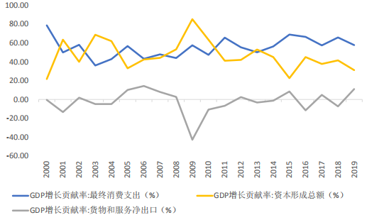

{{% /center %}}

消费和投资对GDP增长的贡献比例比较高

接下来我们需要对消费、投资、净出口分别进行分析，看看是哪个因素导致了GDP增速的升降。

比较遗憾的是，目前支出法GDP的季度数据所显示的信息量比较少，消费、投资、出口等没有更细节的数据。所以我们只能参考一些频率更高、细节更多的相关经济指标，来进行辅助判断。在使用时，须注意它们与GDP指标间的差异。

首先来看消费。目前我国反映消费的指标主要有三个，一是GDP-最终消费支出（年频），二是住户调查中的居民消费支出（季频），三是社会消费品零售总额（月频）。

住户调查中的居民消费支出，是GDP-最终消费支出的主要核算基础资料。但它没有涵盖政府消费支出，并且它披露的只有人均消费支出增速，参考意义有限。

目前，市场上常用社会消费品零售总额，来替代对GDP-最终消费支出的分析。

这个指标与最终消费支出在核算范围方面，存在一些差别：

1）社会消费品零售总额只包括了商品零售、餐饮服务，其他服务性消费支出比如教育医疗支出等，均未被包括在内。而GDP-最终消费支出涵盖了。

2）GDP-最终消费支出还包括了“虚拟消费支出”，比如居民的自有住房服务价值、一些自产自销的商品或服务（比如农产品）、隐含在利息中的金融中介服务等。这些都是社会消费品零售总额不包括的。

3）社会消费品零售总额中，有一些消费行为在GDP中其实是计为投资的，最典型的比如居民建房时买的建筑材料。

不过从历史走势来看，两个指标的增速拟合效果还不错。考虑到暂时还没有其他能够度量消费的更好的指标，现在不妨先用它来判断消费状况的大体变化。 {{% center %}}

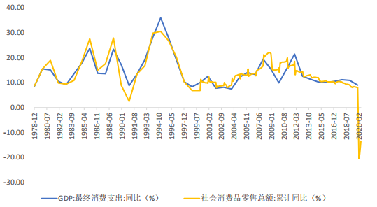

{{% /center %}}

GDP-最终消费支出同比不社会消费品零售额同比走势相关

再来看投资。GDP-资本形成总额可以分为固定资本形成总额、存货增加两部分。

固定资本形成总额占绝对主体，一般占95%以上，而存货增加占比很小。我们一般也只分析固定资本形成总额。

有一个指标，与固定资本形成总额长得非常像：固定资产投资完成额。它反映了全社会建造和购买固定资产的工作量和相关费用。

固定资本形成总额、固定资产投资完成额，两者有区别，它们存在一些统计范围方面的差异：

1）固定资产投资完成额只统计500万元及以上的非农户项目（除房地产企业开发地产项目没有规模限制外）。而固定资本形成总额没有以500万元作为门槛，统计了所有规模的项目。这个是最主要的区别。

2）固定资产投资额包含土地购置费、旧建筑物购置费和旧设备购置费等，但固定资本形成总额将它们剔除了。

3）固定资本形成总额还包括了商品房销售增值，以及培育性生物资源、知识产权产品等无形固定资产的增加。固定资产投资额则不包括。

固定资产完成额是个非常重要的指标，市场关注度也很高。

一方面，它是GDP-固定资本形成总额核算时的重要基础资料, 我们在上文中曾提到这一点。另一方面，它是月频数据，时效性很强，而且资料详实、细节丰富。我们平时在分析投资数据的时候，也主要以固定资产完成额为主。

历史上两个指标的变动比较一致，但是在2017-2018年，GDP-固定资本形成总额增速出现大幅抬升，与固定资产投资完成额增速的趋势性下行明显背离。

我们猜测这个背离的形成，主要是因为2017年后GDP核算体系更新，固定资本形成总额将更多的知识产权产品纳入了核算范围，特别是纳入了研究与开发支出这一项，这可能对固定资本形成总额增速造成了扰动。而固定资产完成额并不统计这些，所以不受影响。 {{% center %}}

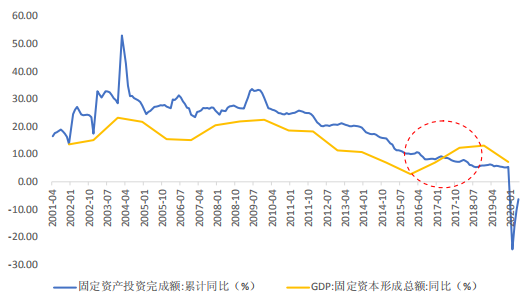

{{% /center %}}

固定资本形成总额同比不固定资产投资完成额同比走势近年出现背离

固定资产投资额数据很全面，可以继续细分为三类主要项目：基建投资、房地产投资、制造业投资——而它们又分别对应着不同的下游需求。限于文章篇幅，我们不再逐个陈述。

最后是货物与服务净出口。目前市场主要分析的是海关统计的月度进出口贸易差额。它与GDP核算的货物与服务净出口有两点主要差异：

1）海关统计的贸易差额，只统计货物贸易，不统计服务贸易。而GDP-货物与服务净出口两者都包括。

2）海关统计的货物进口按到岸价计算，货物与服务净出口统计的货物进口按离岸价计算。两个价格的差异，主要在于国际运费、保险费等。

另外，2014年以后，外管局发布了国际货物和服务贸易进出口月度数据，这个数据和GDP-净出口统计口径更接近，同时包含了货物和服务贸易。我们也可以利用这个数据来拟合GDP-净出口。

不过这个数据一般在次月月末公布，时效性不如海关进出口数据（次月8-10日）。

净出口（或者说贸易差额）等于出口减出口。一般我们在分析的时候，会更关注出口数据一些，因为它直接反映了海外需求，是我国经济总需求分析中的重要部分。

总的来说，支出法是比生产法更重要的GDP分析视角，无论是社会消费品零售额、固定资产投资还是海关进出口数据，都有很多需要进一步仔细甄别的数据细节。我们会在以后的系列报告中，对这些重要指标展开更深入的分析。

## 4.中国GDP历史数据复盘

最后，我们对中国改革开放以来的GDP增长进行一轮简单复盘。

首先可以关注几个比较重要的历史节点：一是1978年中国刚刚开始改革开放；二是2001年中国加入世贸组织；三是2008年全球金融危机；四是2020年新冠疫情。

因此，我们大致将改革开放后的中国经济增长，分为以下几个阶段来讨论：

- 1）1978-2001年：GDP增速总体较快，但波动很大。
- 2）2002-2011年：GDP增速处于较高水平。
- 3）2012年至今：GDP增速趋于下行，2020年1季度大幅回落。  
  {{% center %}}

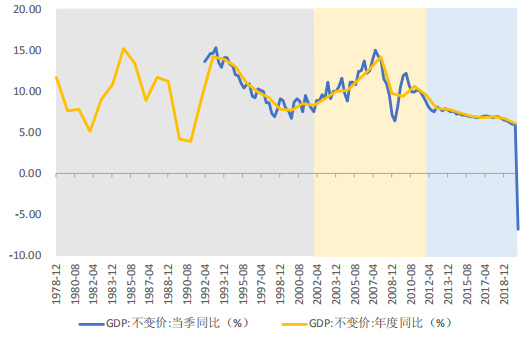

  {{% /center %}}

  改革开放以来的中国GDP同比可以分为三个主要阶段

  我们将每一个阶段（其中第一个阶段又可以分为几个小阶段）的GDP增长，以及各年的生产法、支出法项目对GDP的拉动点数，一并列示在下图中。这样可以比较清楚地显示出各年GDP增长的主要驱动因素。  
  {{% center %}}

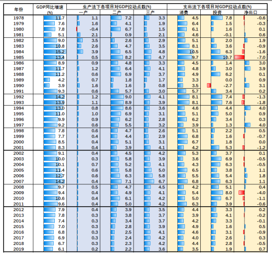

  {{% /center %}}

  各年度生产法、支出法下各项目对于GDP增速的拉动效果

在一个完整的经济分析框架里，人口、城镇化、技术进步、制度变革等一系列长期因素的变动是非常重要的。另外，金融周期对经济周期的影响力也是巨大的。但这些议题太过宏大，我们接下来的分析，偏向于剖析GDP短期波动的触发因素。